# Exercise 4.3

### 02409 Multivariate Statistics

`Week J`

This exercise deals with a univariate regression analysis of data regarding the average marriage age of both men and women and the divorce percentage in Denmark from 1980-2011. The data comes from www.statistikbanken.dk. It is a public site with data published by Danmarks Statistik, which is the central authority on Danish statistics.

The data are presented in the R data set divorce given below. *avgmen*, *avgwomen* and *dp* are the average marriage age of men, average marriage age of women and the divorce percentage respectively.

```r
divorce = data.frame(year = c(1980,1981,1982,1983,1984,1985,1986,1987,1988,1989,1990,1991,1992,1993,1994,1995,1996,1997,1998,1999,2000,2001,2002,2003,2004,2005,2006,2007,2008,2009,2010),
                     avgmen = c(27.5,27.9,28.2,28.5,28.8,29.0,29.2,29.4,29.6,29.8,30.2,30.3,30.7,31.1,31.5,31.7,31.9,32.1,32.4,32.5,32.6,32.8,32.9,33.4,33.7,33.8,33.8,34.1,34.8,34.5,34.6),
                     avgwomen = c(24.8,25.1,25.4,25.8,26.1,26.3,26.5,26.8,27.1,27.4,27.6,27.9,28.2,28.7,29.2,29.3,29.5,29.7,29.9,30.2,30.1,30.3,30.5,31.0,31.4,31.4,31.5,31.8,32.4,32.1,32.1),
                     dp = c(11.79,12.78,12.9,12.73,12.47,12.82,12.94,12.8,13.35,13.91,12.31,11.57,11.81,11.68,11.78,10.48,10.12,9.82,9.82,10.2,10.79,10.98,11.03,11.29,11.08,10.28,9.02,8.21,8.71,9.25,8.86))
```

[figure not shown]

```r
# Recommended packages:
# library(olsrr) # for many interesting plots similar to SAS
# library(lmtest) # for Durbin-Watson D option

# Optional:
# library(ggplot2)
# library(ggpubr) # arrange ggplots
```

**Figure 1**: Data from 1980-2010 of average marriage age for men and women in Denmark and the corresponding divorce rate

In Figure 1 the data for the years 1980-2010 are seen. There is one observation for each year. We can see that within the time period the average age of marriage for both men and women has increased, whereas the divorce percentage within the first five years of marriage has decreased. In this exercise we will investigate the (obvious) correlation between the average age of men and women and the divorce percentage.

**Task 1. Write up the two models that will describe the relationship between marriage age and divorce rate for men and women respectively. This should be done in terms of the General Linear Model.**

**Task 2. In Table 1 the resulting models of the following R code are seen. Do these models correspond to the ones you specified in the previous task?**

| *TABLE 1* | *Model men* | *Model women* |
| --- | --- | --- |
| $\theta_1$ | 29.70795 | 27.25241 |
| $\theta_2$ | -0.58910 | -0.55490 |
| $SS_{res}$ | 18.72969 | 19.28283 |
| $\hat{\sigma}^2$ | 0.64585 | 0.66493 |

```r
# Model men
lmMen <- lm(dp~avgmen,data=divorce)
print("Anova Type I SS:")
anova(lmMen)
summary(lmMen)
```

[output not shown]

```r
# Model women
lmWomen <- lm(dp~avgwomen,data=divorce)
print("Anova Type I SS:")
anova(lmWomen)
summary(lmWomen)
```

[output not shown]

**Task 3. In 2011 the average marriage age for men was 34.8 and 32.4 for women. The divorce percentage was 8.56. What is the expected value of the divorce rate for 2011?**

We are given that for men:

$$\text{Men}: (x^{T}x)^{-1} = \begin{bmatrix} 6.8442 & -0.2170 \\
-0.2170 & 0.0069 \\ \end{bmatrix}$$

And for women:
$$\text{Women}: (x^{T}x)^{-1} = \begin{bmatrix} 5.2126 & -0.1792 \\
-0.1792 & 0.0062 \\ \end{bmatrix}$$

Calculate the confidence and prediction intervals for this new observation for both models.

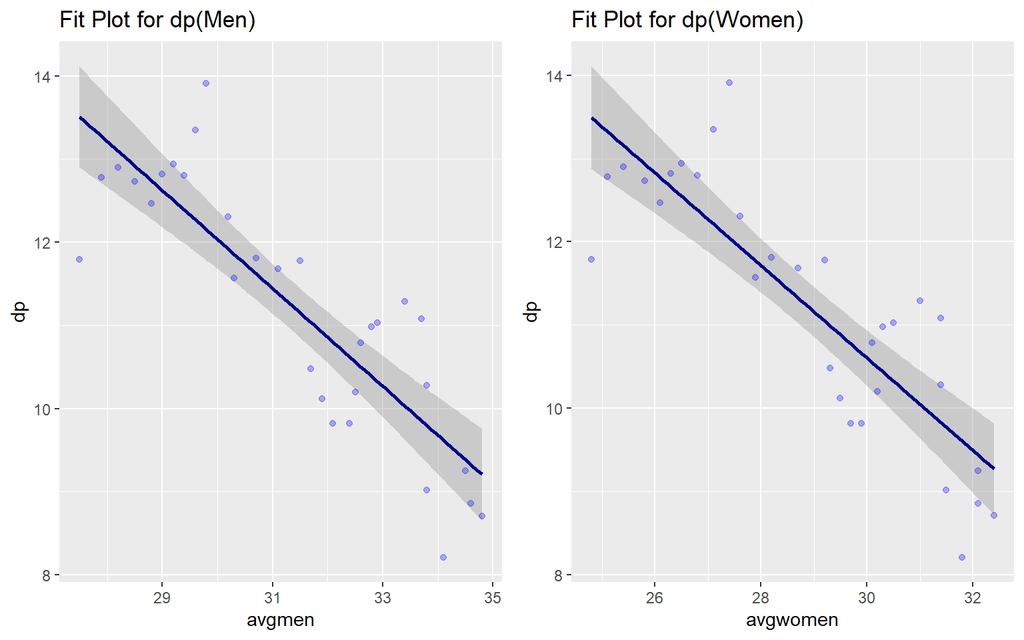